# Risk Factor Analysis

## Outcome Variable

**Outcome Variable:** stunted

## Predictor Variables

**Intervention Variable:** perdiar6

**Adjustment Set:**

unadjusted

## Stratifying Variables

The analysis was stratified on these variable(s):

- agecat
- studyid
- country

## Data Summary

| agecat | studyid | country | perdiar6 | stunted | n_cell | n |
| --- | --- | --- | --- | --- | --- | --- |
| Birth | CMIN | BANGLADESH | 0% | 0 | 10 | 26 |
| Birth | CMIN | BANGLADESH | 0% | 1 | 6 | 26 |
| Birth | CMIN | BANGLADESH | (0%, 5%] | 0 | 2 | 26 |
| Birth | CMIN | BANGLADESH | (0%, 5%] | 1 | 2 | 26 |
| Birth | CMIN | BANGLADESH | >5% | 0 | 5 | 26 |
| Birth | CMIN | BANGLADESH | >5% | 1 | 1 | 26 |
| Birth | CONTENT | PERU | 0% | 0 | 0 | 2 |
| Birth | CONTENT | PERU | 0% | 1 | 0 | 2 |
| Birth | CONTENT | PERU | (0%, 5%] | 0 | 1 | 2 |
| Birth | CONTENT | PERU | (0%, 5%] | 1 | 0 | 2 |
| Birth | CONTENT | PERU | >5% | 0 | 1 | 2 |
| Birth | CONTENT | PERU | >5% | 1 | 0 | 2 |
| Birth | EE | PAKISTAN | 0% | 0 | 132 | 240 |
| Birth | EE | PAKISTAN | 0% | 1 | 91 | 240 |
| Birth | EE | PAKISTAN | (0%, 5%] | 0 | 7 | 240 |
| Birth | EE | PAKISTAN | (0%, 5%] | 1 | 8 | 240 |
| Birth | EE | PAKISTAN | >5% | 0 | 1 | 240 |
| Birth | EE | PAKISTAN | >5% | 1 | 1 | 240 |
| Birth | MAL-ED | BANGLADESH | 0% | 0 | 58 | 231 |
| Birth | MAL-ED | BANGLADESH | 0% | 1 | 14 | 231 |
| Birth | MAL-ED | BANGLADESH | (0%, 5%] | 0 | 78 | 231 |
| Birth | MAL-ED | BANGLADESH | (0%, 5%] | 1 | 12 | 231 |
| Birth | MAL-ED | BANGLADESH | >5% | 0 | 51 | 231 |
| Birth | MAL-ED | BANGLADESH | >5% | 1 | 18 | 231 |
| Birth | MAL-ED | BRAZIL | 0% | 0 | 48 | 65 |
| Birth | MAL-ED | BRAZIL | 0% | 1 | 9 | 65 |
| Birth | MAL-ED | BRAZIL | (0%, 5%] | 0 | 6 | 65 |
| Birth | MAL-ED | BRAZIL | (0%, 5%] | 1 | 0 | 65 |
| Birth | MAL-ED | BRAZIL | >5% | 0 | 2 | 65 |
| Birth | MAL-ED | BRAZIL | >5% | 1 | 0 | 65 |

[output cut: 204 more lines]

The following strata were considered:

- agecat: 24 months, studyid: CMIN, country: BANGLADESH
- agecat: 24 months, studyid: CONTENT, country: PERU
- agecat: 24 months, studyid: EE, country: PAKISTAN
- agecat: 24 months, studyid: MAL-ED, country: BANGLADESH
- agecat: 24 months, studyid: MAL-ED, country: BRAZIL
- agecat: 24 months, studyid: MAL-ED, country: INDIA
- agecat: 24 months, studyid: MAL-ED, country: NEPAL
- agecat: 24 months, studyid: MAL-ED, country: PERU
- agecat: 24 months, studyid: MAL-ED, country: SOUTH AFRICA
- agecat: 24 months, studyid: MAL-ED, country: TANZANIA, UNITED REPUBLIC OF
- agecat: 24 months, studyid: NIH-Birth, country: BANGLADESH
- agecat: 24 months, studyid: NIH-Crypto, country: BANGLADESH
- agecat: 24 months, studyid: PROVIDE, country: BANGLADESH
- agecat: 6 months, studyid: CMIN, country: BANGLADESH
- agecat: 6 months, studyid: CONTENT, country: PERU
- agecat: 6 months, studyid: EE, country: PAKISTAN
- agecat: 6 months, studyid: MAL-ED, country: BANGLADESH
- agecat: 6 months, studyid: MAL-ED, country: BRAZIL
- agecat: 6 months, studyid: MAL-ED, country: INDIA
- agecat: 6 months, studyid: MAL-ED, country: NEPAL
- agecat: 6 months, studyid: MAL-ED, country: PERU
- agecat: 6 months, studyid: MAL-ED, country: SOUTH AFRICA
- agecat: 6 months, studyid: MAL-ED, country: TANZANIA, UNITED REPUBLIC OF
- agecat: 6 months, studyid: NIH-Birth, country: BANGLADESH
- agecat: 6 months, studyid: NIH-Crypto, country: BANGLADESH
- agecat: 6 months, studyid: PROVIDE, country: BANGLADESH
- agecat: Birth, studyid: CMIN, country: BANGLADESH
- agecat: Birth, studyid: CONTENT, country: PERU
- agecat: Birth, studyid: EE, country: PAKISTAN
- agecat: Birth, studyid: MAL-ED, country: BANGLADESH
- agecat: Birth, studyid: MAL-ED, country: BRAZIL
- agecat: Birth, studyid: MAL-ED, country: INDIA
- agecat: Birth, studyid: MAL-ED, country: NEPAL
- agecat: Birth, studyid: MAL-ED, country: PERU
- agecat: Birth, studyid: MAL-ED, country: SOUTH AFRICA
- agecat: Birth, studyid: MAL-ED, country: TANZANIA, UNITED REPUBLIC OF
- agecat: Birth, studyid: NIH-Birth, country: BANGLADESH
- agecat: Birth, studyid: NIH-Crypto, country: BANGLADESH
- agecat: Birth, studyid: PROVIDE, country: BANGLADESH

### Dropped Strata

Some strata were dropped due to rare outcomes:

- agecat: Birth, studyid: CMIN, country: BANGLADESH
- agecat: Birth, studyid: CONTENT, country: PERU
- agecat: Birth, studyid: EE, country: PAKISTAN
- agecat: Birth, studyid: MAL-ED, country: BRAZIL
- agecat: Birth, studyid: MAL-ED, country: INDIA
- agecat: Birth, studyid: MAL-ED, country: NEPAL
- agecat: Birth, studyid: MAL-ED, country: SOUTH AFRICA
- agecat: Birth, studyid: MAL-ED, country: TANZANIA, UNITED REPUBLIC OF
- agecat: 6 months, studyid: CONTENT, country: PERU
- agecat: 6 months, studyid: EE, country: PAKISTAN
- agecat: 6 months, studyid: MAL-ED, country: BRAZIL
- agecat: 6 months, studyid: MAL-ED, country: NEPAL
- agecat: 6 months, studyid: MAL-ED, country: SOUTH AFRICA
- agecat: 24 months, studyid: CONTENT, country: PERU
- agecat: 24 months, studyid: EE, country: PAKISTAN
- agecat: 24 months, studyid: MAL-ED, country: BRAZIL
- agecat: 24 months, studyid: MAL-ED, country: SOUTH AFRICA

## Methods Detail

We’re interested in the causal parameters $E[Y_a]$ for all values of $a \in \mathcal{A}$. These parameters represent the mean outcome if, possibly contrary to fact, we intervened to set all units to have $A=a$. Under the randomization and positivity assumptions, these are identified by the statistical parameters $\psi_a=E_W[E_{Y|A,W}(Y|A=a,W)]$. In addition, we’re interested in the mean of $Y$, $E[Y]$ under no intervention (the observed mean). We will estimate these parameters by using SuperLearner to fit the relevant likelihood factors – $E_{Y|A,W}(Y|A=a,W)$ and $p(A=a|W)$, and then updating our likelihood fit using a joint TMLE.

For unadjusted analyses ($W=\{\}$), initial likelihoods were estimated using Lrnr_glm to estimate the simple $E(Y|A)$ and Lrnr_mean to estimate $p(A)$. For adjusted analyses, a small library containing Lrnr_glmnet, Lrnr_xgboost, and Lrnr_mean was used.

Having estimated these parameters, we will then use the delta method to estimate relative risks and attributable risks relative to a prespecified baseline level of $A$.

# Results Detail

## Results Plots

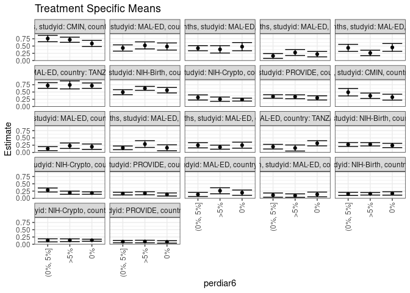

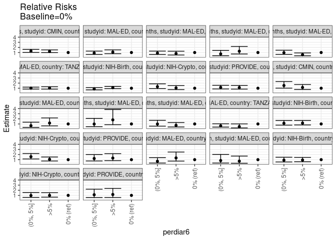

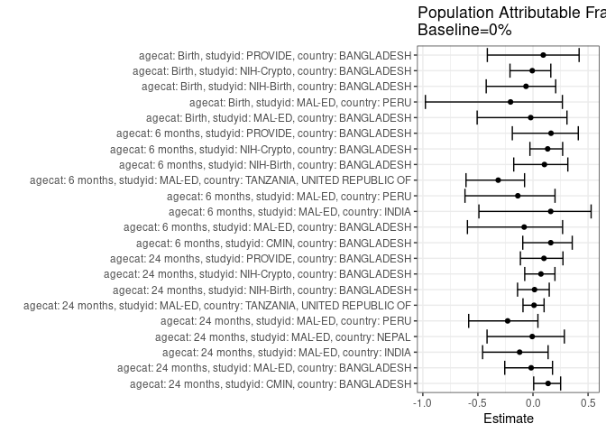

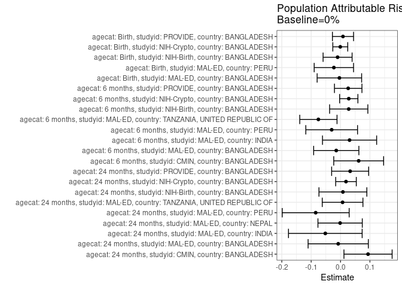

## Results Table

### Parameter: TSM

| agecat | studyid | country | intervention_level | baseline_level | estimate | ci_lower | ci_upper |
| --- | --- | --- | --- | --- | --- | --- | --- |
| Birth | MAL-ED | BANGLADESH | 0% | NA | 0.1944444 | 0.1028288 | 0.2860600 |
| Birth | MAL-ED | BANGLADESH | (0%, 5%] | NA | 0.1333333 | 0.0629509 | 0.2037158 |
| Birth | MAL-ED | BANGLADESH | >5% | NA | 0.2608696 | 0.1570360 | 0.3647032 |
| Birth | MAL-ED | PERU | 0% | NA | 0.1343284 | 0.0524998 | 0.2161570 |
| Birth | MAL-ED | PERU | (0%, 5%] | NA | 0.1111111 | 0.0383636 | 0.1838586 |
| Birth | MAL-ED | PERU | >5% | NA | 0.0957447 | 0.0361344 | 0.1553549 |
| Birth | NIH-Birth | BANGLADESH | 0% | NA | 0.1687500 | 0.1106689 | 0.2268311 |
| Birth | NIH-Birth | BANGLADESH | (0%, 5%] | NA | 0.1525424 | 0.0995303 | 0.2055545 |
| Birth | NIH-Birth | BANGLADESH | >5% | NA | 0.1567164 | 0.1131568 | 0.2002760 |
| Birth | NIH-Crypto | BANGLADESH | 0% | NA | 0.1388889 | 0.1031405 | 0.1746373 |
| Birth | NIH-Crypto | BANGLADESH | (0%, 5%] | NA | 0.1349693 | 0.0824784 | 0.1874603 |
| Birth | NIH-Crypto | BANGLADESH | >5% | NA | 0.1387560 | 0.0918573 | 0.1856547 |
| Birth | PROVIDE | BANGLADESH | 0% | NA | 0.0807453 | 0.0386228 | 0.1228679 |
| Birth | PROVIDE | BANGLADESH | (0%, 5%] | NA | 0.0909091 | 0.0518982 | 0.1299199 |
| Birth | PROVIDE | BANGLADESH | >5% | NA | 0.0946746 | 0.0504944 | 0.1388547 |
| 6 months | CMIN | BANGLADESH | 0% | NA | 0.3209877 | 0.2191088 | 0.4228665 |
| 6 months | CMIN | BANGLADESH | (0%, 5%] | NA | 0.4915254 | 0.3636977 | 0.6193532 |
| 6 months | CMIN | BANGLADESH | >5% | NA | 0.3689320 | 0.2755558 | 0.4623082 |
| 6 months | MAL-ED | BANGLADESH | 0% | NA | 0.1971831 | 0.1044436 | 0.2899226 |
| 6 months | MAL-ED | BANGLADESH | (0%, 5%] | NA | 0.1304348 | 0.0614736 | 0.1993960 |
| 6 months | MAL-ED | BANGLADESH | >5% | NA | 0.2307692 | 0.1370732 | 0.3244652 |
| 6 months | MAL-ED | INDIA | 0% | NA | 0.1600000 | 0.0581679 | 0.2618321 |
| 6 months | MAL-ED | INDIA | (0%, 5%] | NA | 0.1574803 | 0.0939953 | 0.2209654 |
| 6 months | MAL-ED | INDIA | >5% | NA | 0.2881356 | 0.1723269 | 0.4039443 |
| 6 months | MAL-ED | PERU | 0% | NA | 0.2500000 | 0.1468923 | 0.3531077 |
| 6 months | MAL-ED | PERU | (0%, 5%] | NA | 0.2471910 | 0.1574050 | 0.3369770 |
| 6 months | MAL-ED | PERU | >5% | NA | 0.1810345 | 0.1108357 | 0.2512332 |
| 6 months | MAL-ED | TANZANIA, UNITED REPUBLIC OF | 0% | NA | 0.3142857 | 0.2253107 | 0.4032608 |
| 6 months | MAL-ED | TANZANIA, UNITED REPUBLIC OF | (0%, 5%] | NA | 0.1979167 | 0.1180539 | 0.2777794 |
| 6 months | MAL-ED | TANZANIA, UNITED REPUBLIC OF | >5% | NA | 0.1521739 | 0.0481643 | 0.2561836 |
| 6 months | NIH-Birth | BANGLADESH | 0% | NA | 0.2403101 | 0.1665091 | 0.3141111 |
| 6 months | NIH-Birth | BANGLADESH | (0%, 5%] | NA | 0.2721893 | 0.2050226 | 0.3393561 |
| 6 months | NIH-Birth | BANGLADESH | >5% | NA | 0.2803347 | 0.2233370 | 0.3373325 |
| 6 months | NIH-Crypto | BANGLADESH | 0% | NA | 0.1818182 | 0.1408527 | 0.2227837 |
| 6 months | NIH-Crypto | BANGLADESH | (0%, 5%] | NA | 0.2874251 | 0.2187386 | 0.3561117 |
| 6 months | NIH-Crypto | BANGLADESH | >5% | NA | 0.1932367 | 0.1394116 | 0.2470618 |
| 6 months | PROVIDE | BANGLADESH | 0% | NA | 0.1329114 | 0.0799338 | 0.1858890 |
| 6 months | PROVIDE | BANGLADESH | (0%, 5%] | NA | 0.1626016 | 0.1164519 | 0.2087513 |
| 6 months | PROVIDE | BANGLADESH | >5% | NA | 0.1750000 | 0.1222966 | 0.2277034 |
| 24 months | CMIN | BANGLADESH | 0% | NA | 0.5882353 | 0.4833927 | 0.6930779 |
| 24 months | CMIN | BANGLADESH | (0%, 5%] | NA | 0.7586207 | 0.6482648 | 0.8689766 |
| 24 months | CMIN | BANGLADESH | >5% | NA | 0.7171717 | 0.6282715 | 0.8060719 |
| 24 months | MAL-ED | BANGLADESH | 0% | NA | 0.4843750 | 0.3616473 | 0.6071027 |
| 24 months | MAL-ED | BANGLADESH | (0%, 5%] | NA | 0.4337349 | 0.3268644 | 0.5406054 |
| 24 months | MAL-ED | BANGLADESH | >5% | NA | 0.5230769 | 0.4013673 | 0.6447866 |
| 24 months | MAL-ED | INDIA | 0% | NA | 0.4791667 | 0.3375290 | 0.6208044 |
| 24 months | MAL-ED | INDIA | (0%, 5%] | NA | 0.4262295 | 0.3382832 | 0.5141758 |
| 24 months | MAL-ED | INDIA | >5% | NA | 0.3859649 | 0.2593048 | 0.5126250 |
| 24 months | MAL-ED | NEPAL | 0% | NA | 0.2207792 | 0.1279325 | 0.3136259 |
| 24 months | MAL-ED | NEPAL | (0%, 5%] | NA | 0.1600000 | 0.0768482 | 0.2431518 |
| 24 months | MAL-ED | NEPAL | >5% | NA | 0.2763158 | 0.1755593 | 0.3770723 |
| 24 months | MAL-ED | PERU | 0% | NA | 0.4528302 | 0.3184851 | 0.5871753 |
| 24 months | MAL-ED | PERU | (0%, 5%] | NA | 0.4375000 | 0.3156596 | 0.5593404 |
| 24 months | MAL-ED | PERU | >5% | NA | 0.2619048 | 0.1676465 | 0.3561630 |
| 24 months | MAL-ED | TANZANIA, UNITED REPUBLIC OF | 0% | NA | 0.7173913 | 0.6251677 | 0.8096149 |
| 24 months | MAL-ED | TANZANIA, UNITED REPUBLIC OF | (0%, 5%] | NA | 0.7228916 | 0.6263782 | 0.8194050 |
| 24 months | MAL-ED | TANZANIA, UNITED REPUBLIC OF | >5% | NA | 0.7435897 | 0.6062275 | 0.8809520 |
| 24 months | NIH-Birth | BANGLADESH | 0% | NA | 0.5607477 | 0.4666013 | 0.6548941 |
| 24 months | NIH-Birth | BANGLADESH | (0%, 5%] | NA | 0.4921875 | 0.4054780 | 0.5788970 |
| 24 months | NIH-Birth | BANGLADESH | >5% | NA | 0.6237113 | 0.5554608 | 0.6919619 |
| 24 months | NIH-Crypto | BANGLADESH | 0% | NA | 0.2382671 | 0.1880486 | 0.2884857 |
| 24 months | NIH-Crypto | BANGLADESH | (0%, 5%] | NA | 0.3113208 | 0.2230879 | 0.3995537 |
| 24 months | NIH-Crypto | BANGLADESH | >5% | NA | 0.2519084 | 0.1774979 | 0.3263189 |
| 24 months | PROVIDE | BANGLADESH | 0% | NA | 0.2960526 | 0.2234158 | 0.3686895 |
| 24 months | PROVIDE | BANGLADESH | (0%, 5%] | NA | 0.3448276 | 0.2836124 | 0.4060427 |
| 24 months | PROVIDE | BANGLADESH | >5% | NA | 0.3350515 | 0.2685743 | 0.4015288 |

### Parameter: E(Y)

| agecat | studyid | country | intervention_level | baseline_level | estimate | ci_lower | ci_upper |
| --- | --- | --- | --- | --- | --- | --- | --- |
| Birth | MAL-ED | BANGLADESH | NA | NA | 0.1904762 | 0.1397281 | 0.2412242 |
| Birth | MAL-ED | PERU | NA | NA | 0.1115880 | 0.0710726 | 0.1521034 |
| Birth | NIH-Birth | BANGLADESH | NA | NA | 0.1586777 | 0.1295391 | 0.1878163 |
| Birth | NIH-Crypto | BANGLADESH | NA | NA | 0.1379781 | 0.1129774 | 0.1629789 |
| Birth | PROVIDE | BANGLADESH | NA | NA | 0.0890538 | 0.0649864 | 0.1131212 |
| 6 months | CMIN | BANGLADESH | NA | NA | 0.3827160 | 0.3214780 | 0.4439541 |
| 6 months | MAL-ED | BANGLADESH | NA | NA | 0.1825726 | 0.1336978 | 0.2314474 |
| 6 months | MAL-ED | INDIA | NA | NA | 0.1906780 | 0.1404524 | 0.2409036 |
| 6 months | MAL-ED | PERU | NA | NA | 0.2197802 | 0.1705687 | 0.2689917 |
| 6 months | MAL-ED | TANZANIA, UNITED REPUBLIC OF | NA | NA | 0.2388664 | 0.1855834 | 0.2921494 |
| 6 months | NIH-Birth | BANGLADESH | NA | NA | 0.2681564 | 0.2306532 | 0.3056597 |
| 6 months | NIH-Crypto | BANGLADESH | NA | NA | 0.2097902 | 0.1799252 | 0.2396552 |
| 6 months | PROVIDE | BANGLADESH | NA | NA | 0.1589404 | 0.1297581 | 0.1881227 |
| 24 months | CMIN | BANGLADESH | NA | NA | 0.6818182 | 0.6230135 | 0.7406228 |
| 24 months | MAL-ED | BANGLADESH | NA | NA | 0.4764151 | 0.4090254 | 0.5438047 |
| 24 months | MAL-ED | INDIA | NA | NA | 0.4273128 | 0.3628178 | 0.4918077 |
| 24 months | MAL-ED | NEPAL | NA | NA | 0.2192982 | 0.1654718 | 0.2731246 |
| 24 months | MAL-ED | PERU | NA | NA | 0.3681592 | 0.3013164 | 0.4350020 |
| 24 months | MAL-ED | TANZANIA, UNITED REPUBLIC OF | NA | NA | 0.7242991 | 0.6642873 | 0.7843108 |
| 24 months | NIH-Birth | BANGLADESH | NA | NA | 0.5687646 | 0.5218455 | 0.6156837 |
| 24 months | NIH-Crypto | BANGLADESH | NA | NA | 0.2568093 | 0.2190047 | 0.2946140 |
| 24 months | PROVIDE | BANGLADESH | NA | NA | 0.3287197 | 0.2903909 | 0.3670485 |

### Parameter: RR

| agecat | studyid | country | intervention_level | baseline_level | estimate | ci_lower | ci_upper |
| --- | --- | --- | --- | --- | --- | --- | --- |
| Birth | MAL-ED | BANGLADESH | 0% | 0% | 1.0000000 | 1.0000000 | 1.0000000 |
| Birth | MAL-ED | BANGLADESH | (0%, 5%] | 0% | 0.6857143 | 0.3379508 | 1.3913390 |
| Birth | MAL-ED | BANGLADESH | >5% | 0% | 1.3416149 | 0.7240380 | 2.4859614 |
| Birth | MAL-ED | PERU | 0% | 0% | 1.0000000 | 1.0000000 | 1.0000000 |
| Birth | MAL-ED | PERU | (0%, 5%] | 0% | 0.8271605 | 0.3382241 | 2.0229029 |
| Birth | MAL-ED | PERU | >5% | 0% | 0.7127660 | 0.2983038 | 1.7030804 |
| Birth | NIH-Birth | BANGLADESH | 0% | 0% | 1.0000000 | 1.0000000 | 1.0000000 |
| Birth | NIH-Birth | BANGLADESH | (0%, 5%] | 0% | 0.9039548 | 0.5542757 | 1.4742381 |
| Birth | NIH-Birth | BANGLADESH | >5% | 0% | 0.9286899 | 0.5966748 | 1.4454523 |
| Birth | NIH-Crypto | BANGLADESH | 0% | 0% | 1.0000000 | 1.0000000 | 1.0000000 |
| Birth | NIH-Crypto | BANGLADESH | (0%, 5%] | 0% | 0.9717791 | 0.6095735 | 1.5492057 |
| Birth | NIH-Crypto | BANGLADESH | >5% | 0% | 0.9990431 | 0.6532487 | 1.5278821 |
| Birth | PROVIDE | BANGLADESH | 0% | 0% | 1.0000000 | 1.0000000 | 1.0000000 |
| Birth | PROVIDE | BANGLADESH | (0%, 5%] | 0% | 1.1258741 | 0.5729659 | 2.2123352 |
| Birth | PROVIDE | BANGLADESH | >5% | 0% | 1.1725080 | 0.5822892 | 2.3609832 |
| 6 months | CMIN | BANGLADESH | 0% | 0% | 1.0000000 | 1.0000000 | 1.0000000 |
| 6 months | CMIN | BANGLADESH | (0%, 5%] | 0% | 1.5312907 | 1.0159064 | 2.3081371 |
| 6 months | CMIN | BANGLADESH | >5% | 0% | 1.1493652 | 0.7658710 | 1.7248863 |
| 6 months | MAL-ED | BANGLADESH | 0% | 0% | 1.0000000 | 1.0000000 | 1.0000000 |
| 6 months | MAL-ED | BANGLADESH | (0%, 5%] | 0% | 0.6614907 | 0.3259923 | 1.3422708 |
| 6 months | MAL-ED | BANGLADESH | >5% | 0% | 1.1703297 | 0.6287352 | 2.1784552 |
| 6 months | MAL-ED | INDIA | 0% | 0% | 1.0000000 | 1.0000000 | 1.0000000 |
| 6 months | MAL-ED | INDIA | (0%, 5%] | 0% | 0.9842520 | 0.4633583 | 2.0907189 |
| 6 months | MAL-ED | INDIA | >5% | 0% | 1.8008475 | 0.8483352 | 3.8228424 |
| 6 months | MAL-ED | PERU | 0% | 0% | 1.0000000 | 1.0000000 | 1.0000000 |
| 6 months | MAL-ED | PERU | (0%, 5%] | 0% | 0.9887640 | 0.5707102 | 1.7130487 |
| 6 months | MAL-ED | PERU | >5% | 0% | 0.7241379 | 0.4111218 | 1.2754754 |
| 6 months | MAL-ED | TANZANIA, UNITED REPUBLIC OF | 0% | 0% | 1.0000000 | 1.0000000 | 1.0000000 |
| 6 months | MAL-ED | TANZANIA, UNITED REPUBLIC OF | (0%, 5%] | 0% | 0.6297348 | 0.3846662 | 1.0309354 |
| 6 months | MAL-ED | TANZANIA, UNITED REPUBLIC OF | >5% | 0% | 0.4841897 | 0.2310592 | 1.0146303 |
| 6 months | NIH-Birth | BANGLADESH | 0% | 0% | 1.0000000 | 1.0000000 | 1.0000000 |
| 6 months | NIH-Birth | BANGLADESH | (0%, 5%] | 0% | 1.1326589 | 0.7638405 | 1.6795603 |
| 6 months | NIH-Birth | BANGLADESH | >5% | 0% | 1.1665542 | 0.8071400 | 1.6860132 |
| 6 months | NIH-Crypto | BANGLADESH | 0% | 0% | 1.0000000 | 1.0000000 | 1.0000000 |
| 6 months | NIH-Crypto | BANGLADESH | (0%, 5%] | 0% | 1.5808383 | 1.1382775 | 2.1954662 |
| 6 months | NIH-Crypto | BANGLADESH | >5% | 0% | 1.0628019 | 0.7427813 | 1.5207006 |
| 6 months | PROVIDE | BANGLADESH | 0% | 0% | 1.0000000 | 1.0000000 | 1.0000000 |
| 6 months | PROVIDE | BANGLADESH | (0%, 5%] | 0% | 1.2233837 | 0.7499895 | 1.9955848 |
| 6 months | PROVIDE | BANGLADESH | >5% | 0% | 1.3166667 | 0.7989380 | 2.1698945 |
| 24 months | CMIN | BANGLADESH | 0% | 0% | 1.0000000 | 1.0000000 | 1.0000000 |
| 24 months | CMIN | BANGLADESH | (0%, 5%] | 0% | 1.2896552 | 1.0246118 | 1.6232591 |
| 24 months | CMIN | BANGLADESH | >5% | 0% | 1.2191919 | 0.9812652 | 1.5148085 |
| 24 months | MAL-ED | BANGLADESH | 0% | 0% | 1.0000000 | 1.0000000 | 1.0000000 |
| 24 months | MAL-ED | BANGLADESH | (0%, 5%] | 0% | 0.8954528 | 0.6288576 | 1.2750672 |
| 24 months | MAL-ED | BANGLADESH | >5% | 0% | 1.0799007 | 0.7655705 | 1.5232897 |
| 24 months | MAL-ED | INDIA | 0% | 0% | 1.0000000 | 1.0000000 | 1.0000000 |
| 24 months | MAL-ED | INDIA | (0%, 5%] | 0% | 0.8895225 | 0.6202983 | 1.2755962 |
| 24 months | MAL-ED | INDIA | >5% | 0% | 0.8054920 | 0.5179039 | 1.2527755 |
| 24 months | MAL-ED | NEPAL | 0% | 0% | 1.0000000 | 1.0000000 | 1.0000000 |
| 24 months | MAL-ED | NEPAL | (0%, 5%] | 0% | 0.7247059 | 0.3713812 | 1.4141766 |
| 24 months | MAL-ED | NEPAL | >5% | 0% | 1.2515480 | 0.7173204 | 2.1836441 |
| 24 months | MAL-ED | PERU | 0% | 0% | 1.0000000 | 1.0000000 | 1.0000000 |
| 24 months | MAL-ED | PERU | (0%, 5%] | 0% | 0.9661458 | 0.6431668 | 1.4513153 |
| 24 months | MAL-ED | PERU | >5% | 0% | 0.5783730 | 0.3627827 | 0.9220818 |
| 24 months | MAL-ED | TANZANIA, UNITED REPUBLIC OF | 0% | 0% | 1.0000000 | 1.0000000 | 1.0000000 |
| 24 months | MAL-ED | TANZANIA, UNITED REPUBLIC OF | (0%, 5%] | 0% | 1.0076670 | 0.8371912 | 1.2128566 |
| 24 months | MAL-ED | TANZANIA, UNITED REPUBLIC OF | >5% | 0% | 1.0365190 | 0.8276299 | 1.2981307 |
| 24 months | NIH-Birth | BANGLADESH | 0% | 0% | 1.0000000 | 1.0000000 | 1.0000000 |
| 24 months | NIH-Birth | BANGLADESH | (0%, 5%] | 0% | 0.8777344 | 0.6881330 | 1.1195767 |
| 24 months | NIH-Birth | BANGLADESH | >5% | 0% | 1.1122852 | 0.9102921 | 1.3591004 |
| 24 months | NIH-Crypto | BANGLADESH | 0% | 0% | 1.0000000 | 1.0000000 | 1.0000000 |
| 24 months | NIH-Crypto | BANGLADESH | (0%, 5%] | 0% | 1.3066038 | 0.9178117 | 1.8600912 |
| 24 months | NIH-Crypto | BANGLADESH | >5% | 0% | 1.0572519 | 0.7355046 | 1.5197480 |
| 24 months | PROVIDE | BANGLADESH | 0% | 0% | 1.0000000 | 1.0000000 | 1.0000000 |
| 24 months | PROVIDE | BANGLADESH | (0%, 5%] | 0% | 1.1647510 | 0.8604219 | 1.5767204 |
| 24 months | PROVIDE | BANGLADESH | >5% | 0% | 1.1317297 | 0.8254807 | 1.5515953 |

### Parameter: PAR

| agecat | studyid | country | intervention_level | baseline_level | estimate | ci_lower | ci_upper |
| --- | --- | --- | --- | --- | --- | --- | --- |
| Birth | MAL-ED | BANGLADESH | 0% | NA | -0.0039683 | -0.0797081 | 0.0717716 |
| Birth | MAL-ED | PERU | 0% | NA | -0.0227404 | -0.0897220 | 0.0442413 |
| Birth | NIH-Birth | BANGLADESH | 0% | NA | -0.0100723 | -0.0594503 | 0.0393057 |
| Birth | NIH-Crypto | BANGLADESH | 0% | NA | -0.0009107 | -0.0263271 | 0.0245056 |
| Birth | PROVIDE | BANGLADESH | 0% | NA | 0.0083085 | -0.0276578 | 0.0442748 |
| 6 months | CMIN | BANGLADESH | 0% | NA | 0.0617284 | -0.0231825 | 0.1466393 |
| 6 months | MAL-ED | BANGLADESH | 0% | NA | -0.0146105 | -0.0915636 | 0.0623426 |
| 6 months | MAL-ED | INDIA | 0% | NA | 0.0306780 | -0.0615089 | 0.1228648 |
| 6 months | MAL-ED | PERU | 0% | NA | -0.0302198 | -0.1182927 | 0.0578531 |
| 6 months | MAL-ED | TANZANIA, UNITED REPUBLIC OF | 0% | NA | -0.0754193 | -0.1388619 | -0.0119768 |
| 6 months | NIH-Birth | BANGLADESH | 0% | NA | 0.0278463 | -0.0372404 | 0.0929331 |
| 6 months | NIH-Crypto | BANGLADESH | 0% | NA | 0.0279720 | -0.0031627 | 0.0591068 |
| 6 months | PROVIDE | BANGLADESH | 0% | NA | 0.0260290 | -0.0207670 | 0.0728250 |
| 24 months | CMIN | BANGLADESH | 0% | NA | 0.0935829 | 0.0115565 | 0.1756093 |
| 24 months | MAL-ED | BANGLADESH | 0% | NA | -0.0079599 | -0.1104751 | 0.0945553 |
| 24 months | MAL-ED | INDIA | 0% | NA | -0.0518539 | -0.1773002 | 0.0735925 |
| 24 months | MAL-ED | NEPAL | 0% | NA | -0.0014810 | -0.0769473 | 0.0739854 |
| 24 months | MAL-ED | PERU | 0% | NA | -0.0846710 | -0.1986815 | 0.0293396 |
| 24 months | MAL-ED | TANZANIA, UNITED REPUBLIC OF | 0% | NA | 0.0069078 | -0.0623290 | 0.0761445 |
| 24 months | NIH-Birth | BANGLADESH | 0% | NA | 0.0080169 | -0.0734908 | 0.0895246 |
| 24 months | NIH-Crypto | BANGLADESH | 0% | NA | 0.0185422 | -0.0165709 | 0.0536553 |
| 24 months | PROVIDE | BANGLADESH | 0% | NA | 0.0326671 | -0.0303426 | 0.0956768 |

### Parameter: PAF

| agecat | studyid | country | intervention_level | baseline_level | estimate | ci_lower | ci_upper |
| --- | --- | --- | --- | --- | --- | --- | --- |
| Birth | MAL-ED | BANGLADESH | 0% | NA | -0.0208333 | -0.5069966 | 0.3084917 |
| Birth | MAL-ED | PERU | 0% | NA | -0.2037887 | -0.9767724 | 0.2669326 |
| Birth | NIH-Birth | BANGLADESH | 0% | NA | -0.0634766 | -0.4247991 | 0.2062162 |
| Birth | NIH-Crypto | BANGLADESH | 0% | NA | -0.0066007 | -0.2087344 | 0.1617307 |
| Birth | PROVIDE | BANGLADESH | 0% | NA | 0.0932971 | -0.4144963 | 0.4187966 |
| 6 months | CMIN | BANGLADESH | 0% | NA | 0.1612903 | -0.0927649 | 0.3562806 |
| 6 months | MAL-ED | BANGLADESH | 0% | NA | -0.0800256 | -0.5951790 | 0.2687621 |
| 6 months | MAL-ED | INDIA | 0% | NA | 0.1608889 | -0.4909535 | 0.5277469 |
| 6 months | MAL-ED | PERU | 0% | NA | -0.1375000 | -0.6172885 | 0.1999533 |
| 6 months | MAL-ED | TANZANIA, UNITED REPUBLIC OF | 0% | NA | -0.3157385 | -0.6080477 | -0.0765649 |
| 6 months | NIH-Birth | BANGLADESH | 0% | NA | 0.1038437 | -0.1747295 | 0.3163565 |
| 6 months | NIH-Crypto | BANGLADESH | 0% | NA | 0.1333333 | -0.0277610 | 0.2691773 |
| 6 months | PROVIDE | BANGLADESH | 0% | NA | 0.1637658 | -0.1876537 | 0.4112024 |
| 24 months | CMIN | BANGLADESH | 0% | NA | 0.1372549 | 0.0063616 | 0.2509054 |
| 24 months | MAL-ED | BANGLADESH | 0% | NA | -0.0167079 | -0.2563680 | 0.1772355 |
| 24 months | MAL-ED | INDIA | 0% | NA | -0.1213488 | -0.4574323 | 0.1372339 |
| 24 months | MAL-ED | NEPAL | 0% | NA | -0.0067532 | -0.4170070 | 0.2847233 |
| 24 months | MAL-ED | PERU | 0% | NA | -0.2299847 | -0.5837016 | 0.0447302 |
| 24 months | MAL-ED | TANZANIA, UNITED REPUBLIC OF | 0% | NA | 0.0095372 | -0.0908342 | 0.1006731 |
| 24 months | NIH-Birth | BANGLADESH | 0% | NA | 0.0140953 | -0.1401587 | 0.1474800 |
| 24 months | NIH-Crypto | BANGLADESH | 0% | NA | 0.0722022 | -0.0749429 | 0.1992050 |
| 24 months | PROVIDE | BANGLADESH | 0% | NA | 0.0993767 | -0.1141801 | 0.2720007 |